# FAIRMODE-Plots

Christopher Andersen

2024-03-11

## Data

`FAIRMODE-Plots` contains example data from the `DELTA` tool with observed and modeled concentrations. To create target diagrams and summary reports of this data, we first need to do a few preliminary steps.

First, we source the file `FAIRMODE_Evaluation_functions.R` which contains the necessary functions to load and format the data and create the plots. We then execute the function `ProgramInitialization()` to load required `R` packages and define important parameters:

```r
source("FAIRMODE_Evaluation_functions.R")

ProgramInitialization()
```

Next, we read the `DELTA` tool demo time series data and display the first few rows of the data frame:

```r
UsePrint <- FALSE

Data <- ReadDELTAData(UsePrint)

knitr::kable(head(Data))
```

| date | Station | DELTA_NO2 | DELTA_O3 | DELTA_PM2.5 | DELTA_PM10 | Obs_NO2 | Obs_O3 | Obs_PM2.5 | Obs_PM10 | StationInfo |
| --- | --- | --- | --- | --- | --- | --- | --- | --- | --- | --- |
| 2005-01-01 01:00:00 | MODENA_XX_SETTEMBRE | 49.34645 | 0.0012385 | 63.68007 | 68.18952 | 67 | 4 | NA | 44.2 | DELTA |
| 2005-01-01 02:00:00 | MODENA_XX_SETTEMBRE | 47.94696 | 0.0004176 | 63.68007 | 68.18952 | 67 | 4 | NA | 44.2 | DELTA |
| 2005-01-01 03:00:00 | MODENA_XX_SETTEMBRE | 46.77987 | 0.0002681 | 63.68007 | 68.18952 | 61 | 4 | NA | 44.2 | DELTA |
| 2005-01-01 04:00:00 | MODENA_XX_SETTEMBRE | 45.49080 | 0.0002592 | 63.68007 | 68.18952 | 55 | 6 | NA | 44.2 | DELTA |
| 2005-01-01 05:00:00 | MODENA_XX_SETTEMBRE | 44.92197 | 0.0001405 | 63.68007 | 68.18952 | 57 | 6 | NA | 44.2 | DELTA |
| 2005-01-01 06:00:00 | MODENA_XX_SETTEMBRE | 45.48383 | 0.0000486 | 63.68007 | 68.18952 | 61 | 6 | NA | 44.2 | DELTA |

We observe that the data has an hourly time resolution. To proceed from here, we selects one of the four pollutants `NO2`, `O3`, `PM2.5`, or `PM10`, format the data, and compute the quality indicators (the target plot for `NO2` is based on the hourly data so no averages is performed for this pollutant):

## Target plots

```r
Pol     <- "NO2"

Data2   <- FormatDELTAData(Data, Pol, UsePrint)

StatRep <- FAIRMODEStat(Data2, U_Par, Pol)
```

We can now specify parameters for the target plot and create the plot, first for `NO2`:

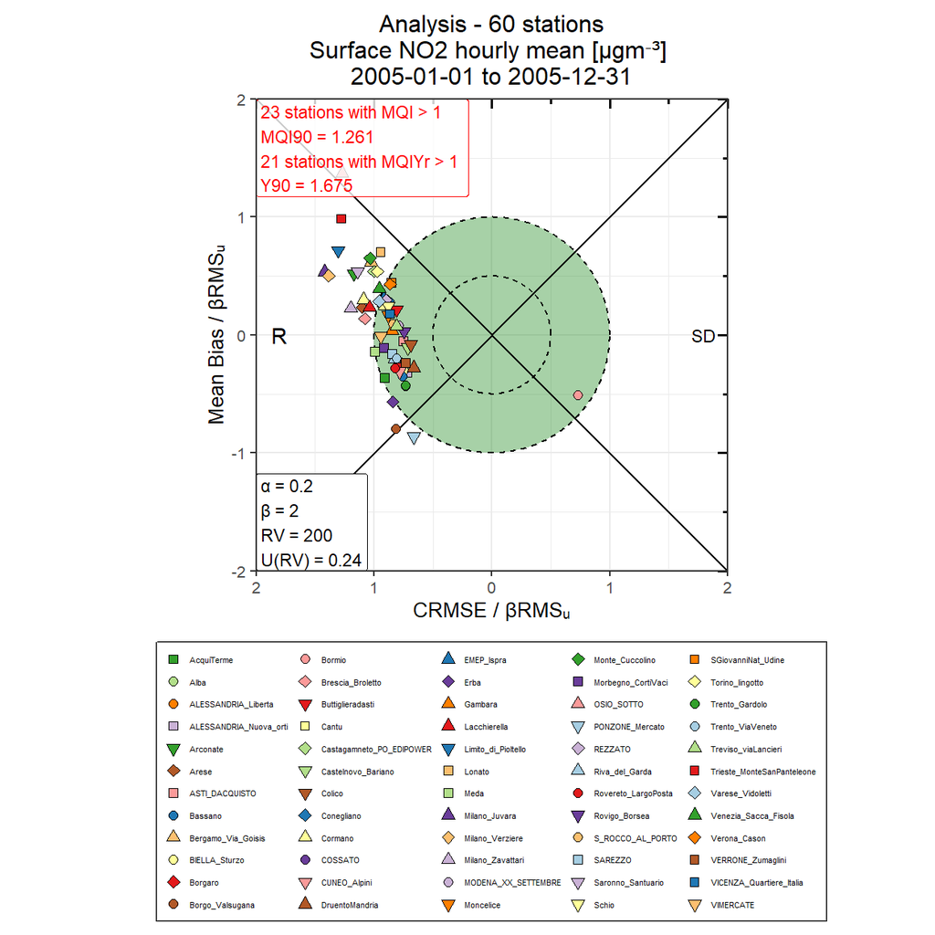

```r
PlotPoint  <- 2 # 1: Standard plot. 2: Each station point is uniquely identifiable (only applicable for fewer than app. 100 stations)
OutputDir  <- "FAIRMODE_Evaluation_Plots/" # Name of the relative output directory of plots to be saved
OutputFile <- FALSE # If not FALSE, "OutputFile" overwrites the default file name. If FALSE, the default file name is used
SavePlot   <- FALSE

TargetPlot(StatRep, PlotPoint, NStations, OutputDir, OutputFile, SavePlot)
```

For `O3`, `FormatDELTAData()` also computes the daily maximum of 8H rolling averages:

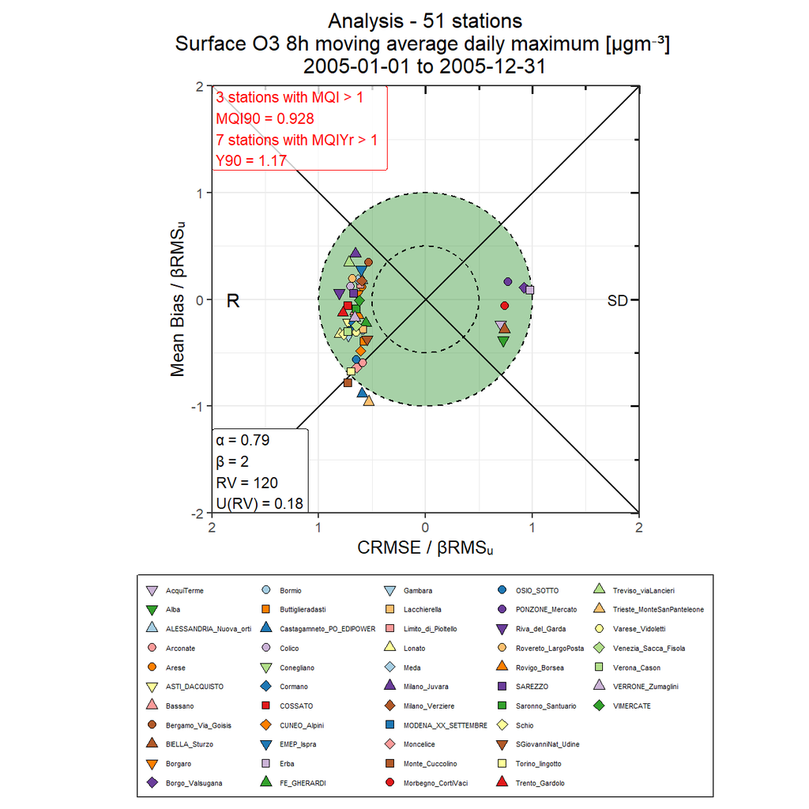

```r
Pol     <- "O3"

Data2   <- FormatDELTAData(Data, Pol, UsePrint)

StatRep <- FAIRMODEStat(Data2, U_Par, Pol)

TargetPlot(StatRep, PlotPoint, NStations, OutputDir, OutputFile, SavePlot)
```

For `PM2.5`, `FormatDELTAData()` also computes the daily averages:

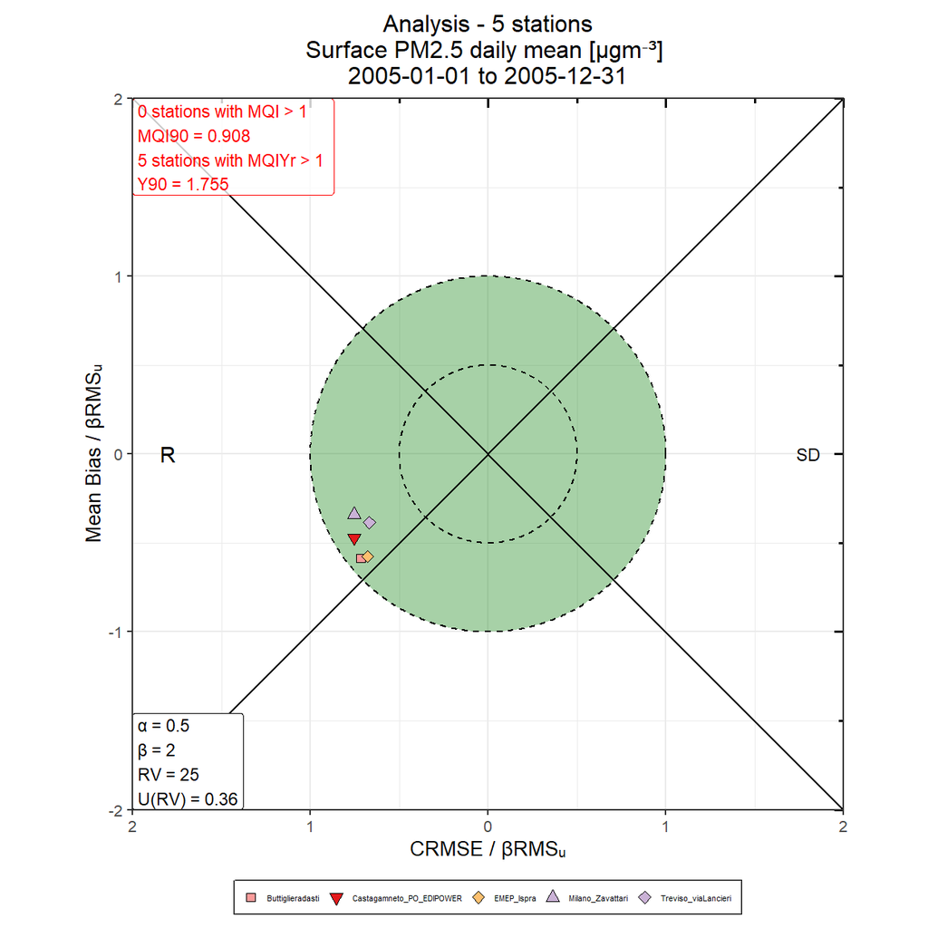

```r
Pol     <- "PM2.5"

Data2   <- FormatDELTAData(Data, Pol, UsePrint)

StatRep <- FAIRMODEStat(Data2, U_Par, Pol)

TargetPlot(StatRep, PlotPoint, NStations, OutputDir, OutputFile, SavePlot)
```

For `PM10`, `FormatDELTAData()` also computes the daily averages:

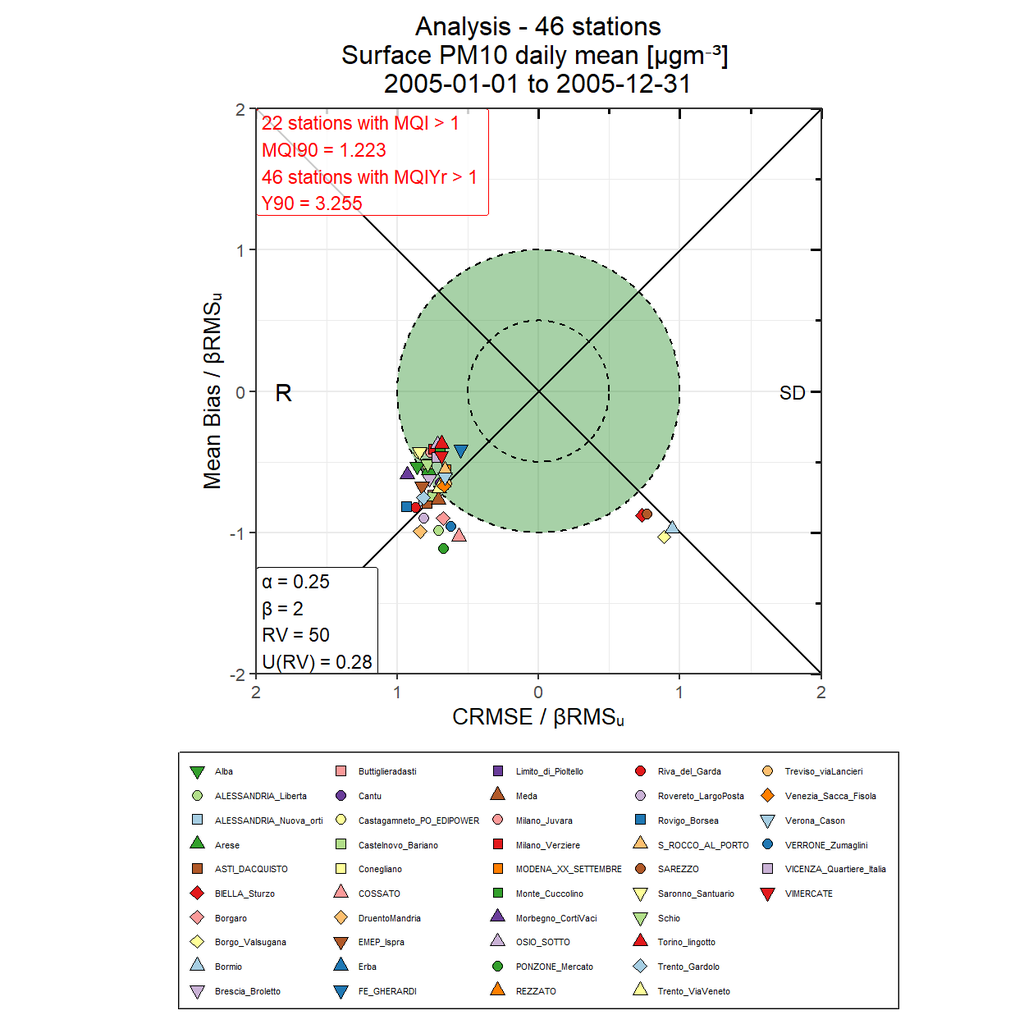

```r
Pol     <- "PM10"

Data2   <- FormatDELTAData(Data, Pol, UsePrint)

StatRep <- FAIRMODEStat(Data2, U_Par, Pol)

TargetPlot(StatRep, PlotPoint, NStations, OutputDir, OutputFile, SavePlot)
```

## Summary reports

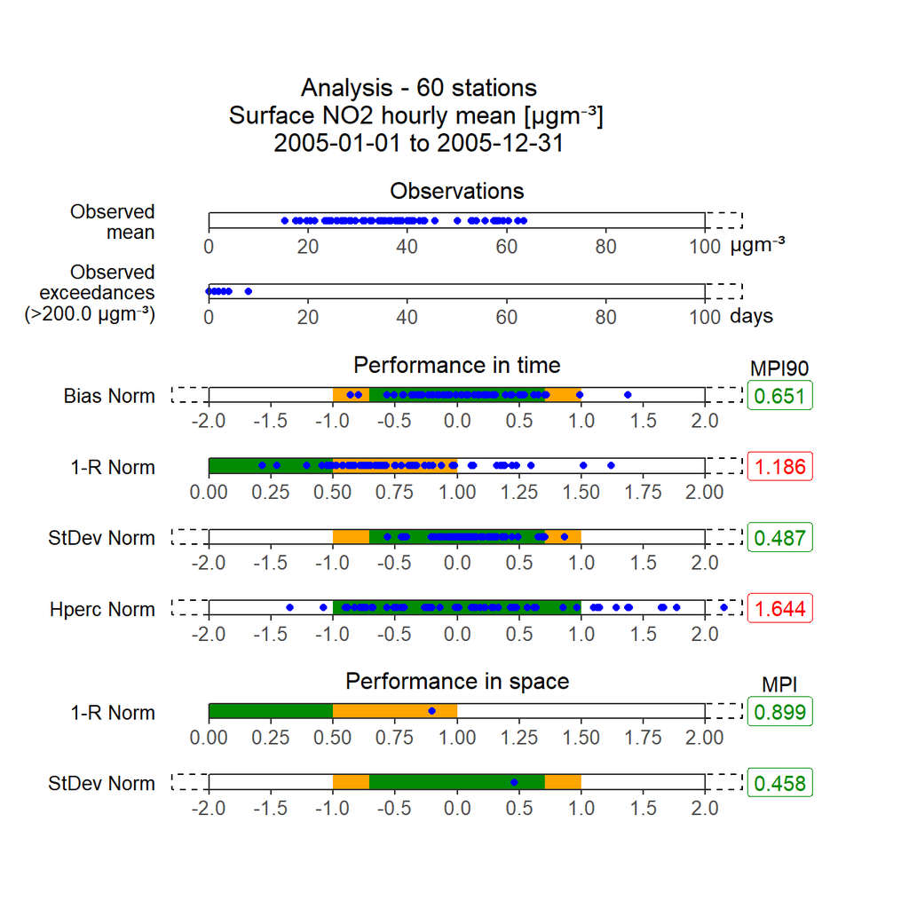

```r
Pol     <- "NO2"

Data2   <- FormatDELTAData(Data, Pol, UsePrint)

StatRep <- FAIRMODEStat(Data2, U_Par, Pol)

PointSize <- 1.5 # Size of points in each subplot of the summary report

SummaryReport(StatRep, Pol, PointSize, OutputDir, OutputFile, SavePlot)
```

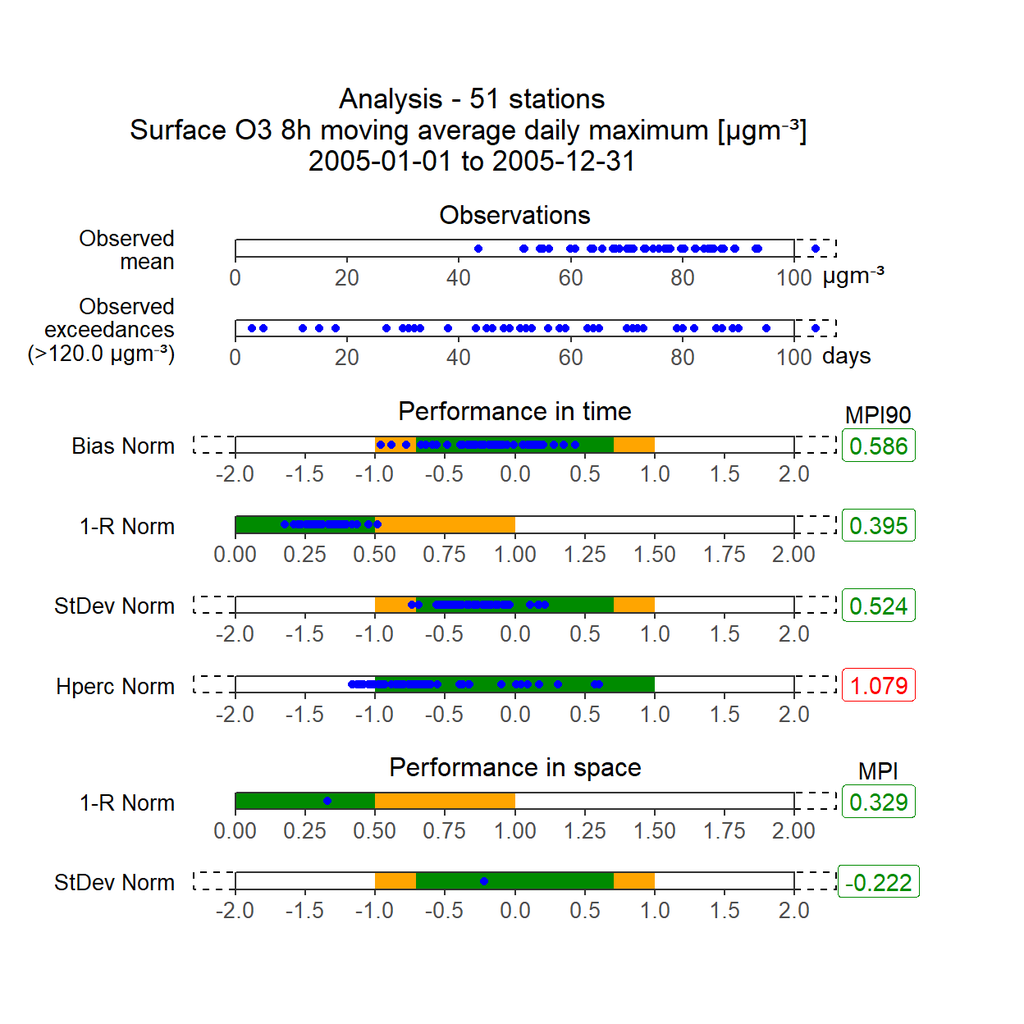

```r
Pol     <- "O3"

Data2   <- FormatDELTAData(Data, Pol, UsePrint)

StatRep <- FAIRMODEStat(Data2, U_Par, Pol)

SummaryReport(StatRep, Pol, PointSize, OutputDir, OutputFile, SavePlot)
```

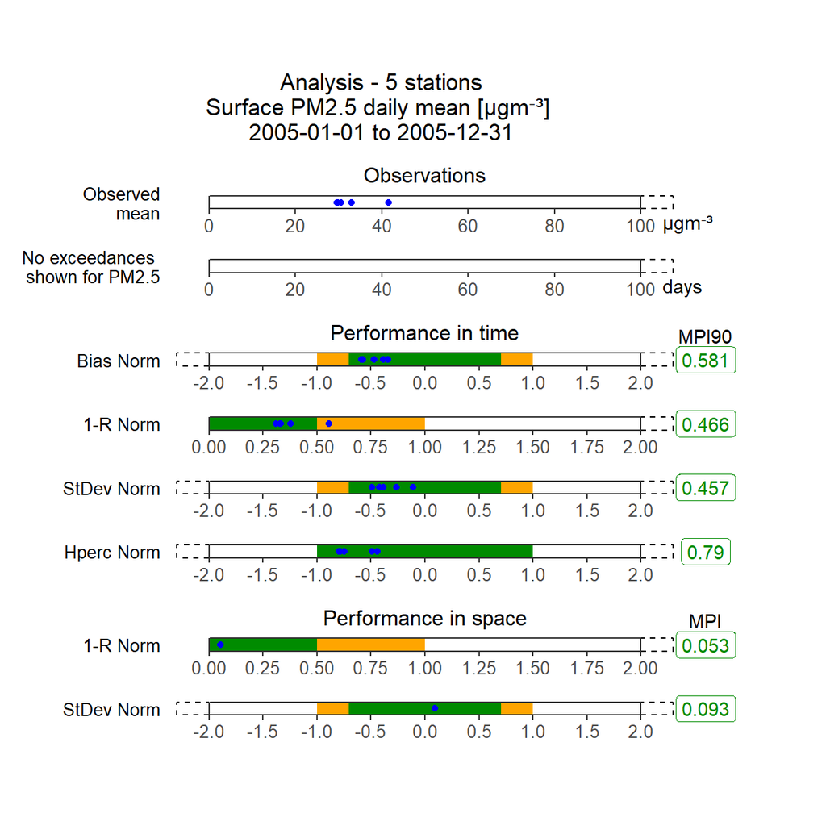

```r
Pol     <- "PM2.5"

Data2   <- FormatDELTAData(Data, Pol, UsePrint)

StatRep <- FAIRMODEStat(Data2, U_Par, Pol)

SummaryReport(StatRep, Pol, PointSize, OutputDir, OutputFile, SavePlot)
```

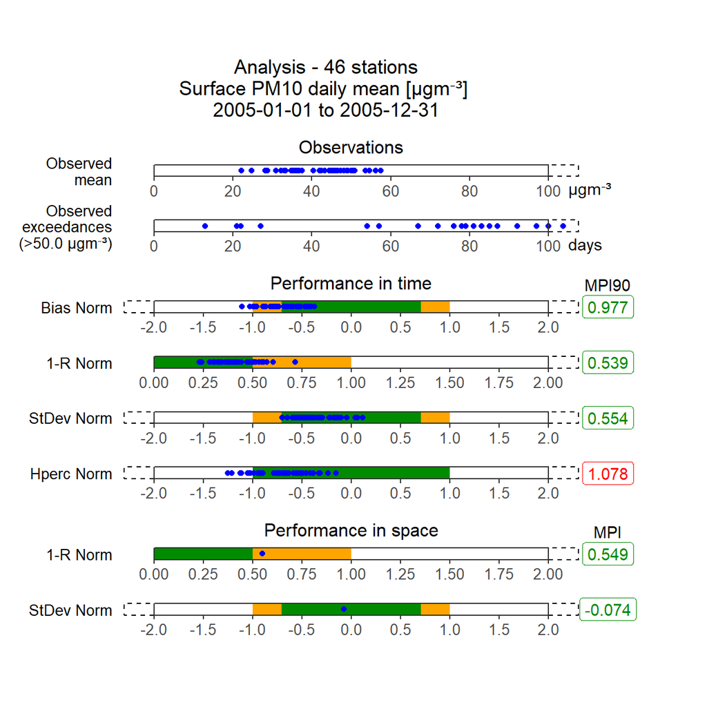

```r
Pol     <- "PM10"

Data2   <- FormatDELTAData(Data, Pol, UsePrint)

StatRep <- FAIRMODEStat(Data2, U_Par, Pol)

SummaryReport(StatRep, Pol, PointSize, OutputDir, OutputFile, SavePlot)
```